13 January 2022

# 1 Lesson 4: mutating joins 2

## 1.1 Learning objectives

1. Mutating joins functions in practice
2. filtering join verbs

In the current lesson we will learn about the last 2 mutating join functions:

- **inner_join()**
- **full_join()**

furthermore, we will also consider 2 more advanced functions which are defined as **filtering join verbs**

- **semi_join()**
- **anti_join()**

```r
library(here)
library(dplyr)
library(readr)
```

### 1.1.1 inner_join

The **inner_join()** simply returns all the rows that have a match in the second dataframe

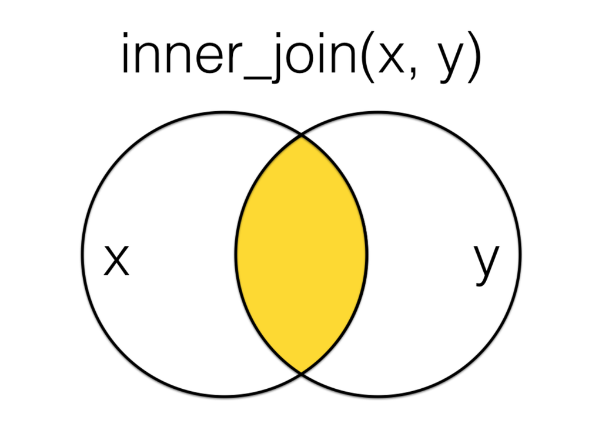

Source: [PsyTeachR](https://psyteachr.github.io/reprores-v2/joins.html)

To test this function we call back the dataframes we used in the previous lesson

```r
yaounde <-
  read_csv(file = here("chapter_xxx_tidy_data/data/yaounde_covid_seroprev_dataset.csv"), show_col_types = FALSE)

yaounde_1 <-
  yaounde %>%
  select("id_quest", "n_hhld_rooms", "n_hhld_adults", "n_hhld_children") %>%
  slice(2:25)

yaounde_2 <-
  yaounde %>%
  select("id_quest", "loc_hhld_area", "loc_hhld_lat", "loc_hhld_long") %>%
  slice(2:20)
```

```r
yaounde_inner_j <-
  inner_join(yaounde_1, yaounde_2, by = "id_quest")

yaounde_inner_j
```

```
## # A tibble: 19 x 7
##    id_quest             n_hhld_rooms n_hhld_adults n_hhld_children loc_hhld_area
##    <chr>                       <dbl>         <dbl>           <dbl> <chr>
##  1 CARRIERE/NUM/002/00~            2             3               1 carriere
##  2 CARRIERE/NUM/002/00~            2             3               1 carriere
##  3 CARRIERE/NUM/038/00~            5             2               4 carriere
##  4 CARRIERE/NUM/038/00~            5             2               4 carriere
##  5 CARRIERE/NUM/015/00~            4             6               1 carriere
##  6 CARRIERE/NUM/005/00~            4             2               2 carriere
##  7 BRIQUETERIE/NUM/012~            5             8               4 briqueterie
##  8 BRIQUETERIE/NUM/019~            7             7               1 briqueterie
##  9 CARRIERE/NUM/014/00~            4             5               0 carriere
## 10 BRIQUETERIE/NUM/014~            4             6               0 briqueterie
## 11 BRIQUETERIE/NUM/029~            4             3               0 briqueterie
## 12 BRIQUETERIE/NUM/029~            4             3               0 briqueterie
## 13 CARRIERE/NUM/065/00~            1             2               1 carriere
## 14 MOKOLO/NUM/019/0002             4             5               3 mokolo
## 15 BRIQUETERIE/NUM/015~            2             2               1 briqueterie
## 16 EKOUDOU/NUM/001/0001            5             2               3 ekoudou
## 17 EKOUDOU/NUM/001/0004            5             2               3 ekoudou
## 18 EKOUDOU/NUM/032/0001            2             2               2 ekoudou
## 19 EKOUDOU/NUM/002/0001            6             9               6 ekoudou
## # ... with 2 more variables: loc_hhld_lat <dbl>, loc_hhld_long <dbl>
```

### 1.1.2 full_join

**full_join()** retain all the rows from the 2 dataframes. When a match is not possible between the dataframes, the rows of the dataframe where the match is missing are filled with NA (similar to what we saw in lesson 3 with left_join)

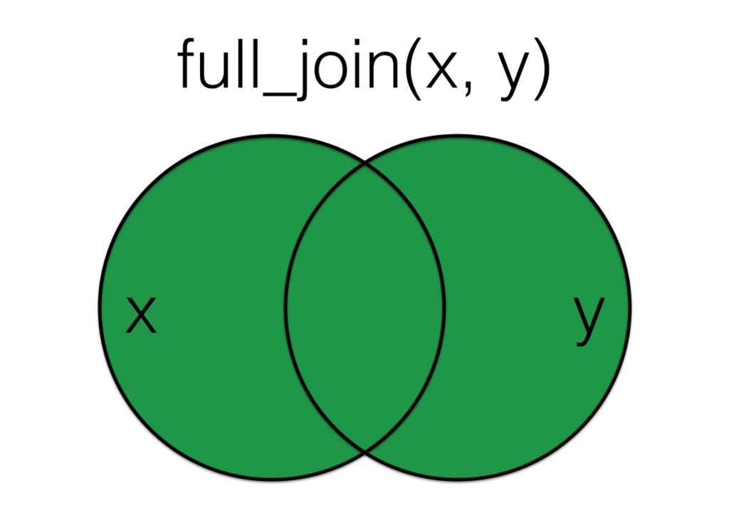

Source: [PsyTeachR](https://psyteachr.github.io/reprores-v2/joins.html)

```r
yaounde_full_j <-
  full_join(yaounde_1, yaounde_2, by = "id_quest")

yaounde_full_j
```

```
## # A tibble: 24 x 7
##    id_quest             n_hhld_rooms n_hhld_adults n_hhld_children loc_hhld_area
##    <chr>                       <dbl>         <dbl>           <dbl> <chr>
##  1 CARRIERE/NUM/002/00~            2             3               1 carriere
##  2 CARRIERE/NUM/002/00~            2             3               1 carriere
##  3 CARRIERE/NUM/038/00~            5             2               4 carriere
##  4 CARRIERE/NUM/038/00~            5             2               4 carriere
##  5 CARRIERE/NUM/015/00~            4             6               1 carriere
##  6 CARRIERE/NUM/005/00~            4             2               2 carriere
##  7 BRIQUETERIE/NUM/012~            5             8               4 briqueterie
##  8 BRIQUETERIE/NUM/019~            7             7               1 briqueterie
##  9 CARRIERE/NUM/014/00~            4             5               0 carriere
## 10 BRIQUETERIE/NUM/014~            4             6               0 briqueterie
## # ... with 14 more rows, and 2 more variables: loc_hhld_lat <dbl>,
## #   loc_hhld_long <dbl>
```

Now we can explore the **filtering_joins()** functions

### 1.1.3 semi_join

**semi_join()** purpose is not to join data but is rather filtering the dataframe on the left based on the matching criteria with the right dataframe

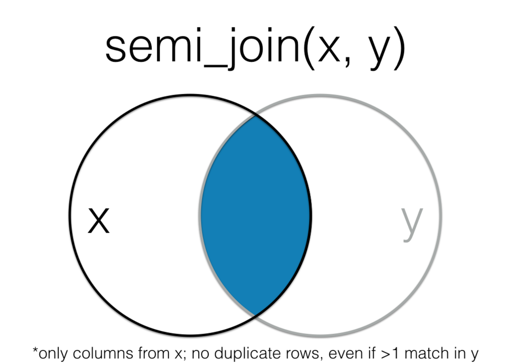

Source: [PsyTeachR](https://psyteachr.github.io/reprores-v2/joins.html)

```r
yaounde_semi_j <-
  semi_join(yaounde_1, yaounde_2, by = "id_quest")

yaounde_semi_j
```

```
## # A tibble: 19 x 4
##    id_quest                 n_hhld_rooms n_hhld_adults n_hhld_children
##    <chr>                           <dbl>         <dbl>           <dbl>
##  1 CARRIERE/NUM/002/0001               2             3               1
##  2 CARRIERE/NUM/002/0002               2             3               1
##  3 CARRIERE/NUM/038/0002               5             2               4
##  4 CARRIERE/NUM/038/0006               5             2               4
##  5 CARRIERE/NUM/015/0002               4             6               1
##  6 CARRIERE/NUM/005/0002               4             2               2
##  7 BRIQUETERIE/NUM/012/0001            5             8               4
##  8 BRIQUETERIE/NUM/019/0004            7             7               1
##  9 CARRIERE/NUM/014/0004               4             5               0
## 10 BRIQUETERIE/NUM/014/0006            4             6               0
## 11 BRIQUETERIE/NUM/029/0002            4             3               0
## 12 BRIQUETERIE/NUM/029/0003            4             3               0
## 13 CARRIERE/NUM/065/0002               1             2               1
## 14 MOKOLO/NUM/019/0002                 4             5               3
## 15 BRIQUETERIE/NUM/015/0002            2             2               1
## 16 EKOUDOU/NUM/001/0001                5             2               3
## 17 EKOUDOU/NUM/001/0004                5             2               3
## 18 EKOUDOU/NUM/032/0001                2             2               2
## 19 EKOUDOU/NUM/002/0001                6             9               6
```

As you see, it returns a dataframe of dimension 19 X 4 where 19 are the matching rows and 4 are the columns from yaounde_1. Interestingly, if you try to duplicate the values in the right dataframe (yaounde_2) **semi_join()** will produce the exact same result because duplicates are not considered. Indeed, the purpose of the second dataframe is just to provide a key to filter the left dataframe

```r
yaounde_2 <-
  yaounde_2 %>%
  slice(rep(1:n(), each = 2))
```

```r
yaounde_semi_j <-
  semi_join(yaounde_1, yaounde_2, by = "id_quest")

yaounde_semi_j
```

```
## # A tibble: 19 x 4
##    id_quest                 n_hhld_rooms n_hhld_adults n_hhld_children
##    <chr>                           <dbl>         <dbl>           <dbl>
##  1 CARRIERE/NUM/002/0001               2             3               1
##  2 CARRIERE/NUM/002/0002               2             3               1
##  3 CARRIERE/NUM/038/0002               5             2               4
##  4 CARRIERE/NUM/038/0006               5             2               4
##  5 CARRIERE/NUM/015/0002               4             6               1
##  6 CARRIERE/NUM/005/0002               4             2               2
##  7 BRIQUETERIE/NUM/012/0001            5             8               4
##  8 BRIQUETERIE/NUM/019/0004            7             7               1
##  9 CARRIERE/NUM/014/0004               4             5               0
## 10 BRIQUETERIE/NUM/014/0006            4             6               0
## 11 BRIQUETERIE/NUM/029/0002            4             3               0
## 12 BRIQUETERIE/NUM/029/0003            4             3               0
## 13 CARRIERE/NUM/065/0002               1             2               1
## 14 MOKOLO/NUM/019/0002                 4             5               3
## 15 BRIQUETERIE/NUM/015/0002            2             2               1
## 16 EKOUDOU/NUM/001/0001                5             2               3
## 17 EKOUDOU/NUM/001/0004                5             2               3
## 18 EKOUDOU/NUM/032/0001                2             2               2
## 19 EKOUDOU/NUM/002/0001                6             9               6
```

### 1.1.4 anti_join

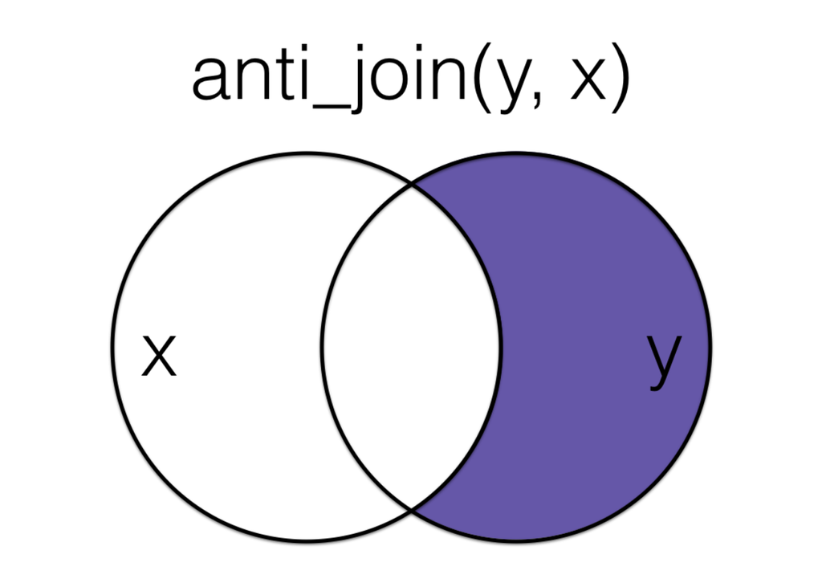

Source: [PsyTeachR](https://psyteachr.github.io/reprores-v2/joins.html)

the last function we cover in this lesson is **anti_join()** and its function is the opposite of **semi_join()** i.e. return all the values that are not matching with the right dataframe

```r
#restore yaounde_2 without duplicates
yaounde_2 <-
  yaounde %>%
  select("id_quest", "loc_hhld_area", "loc_hhld_lat", "loc_hhld_long") %>%
  slice(2:20)
```

```r
yaounde_anti_j <-
  anti_join(yaounde_1, yaounde_2, by = "id_quest")

yaounde_anti_j
```

| id_quest | n_hhld_rooms | n_hhld_adults | n_hhld_children |
| --- | --- | --- | --- |
| EKOUDOU/NUM/002/0008 | 6 | 9 | 6 |
| EKOUDOU/NUM/002/0007 | 6 | 9 | 6 |
| EKOUDOU/NUM/002/0002 | 6 | 9 | 6 |
| MOKOLO/NUM/019/0004 | 4 | 5 | 3 |
| CARRIERE/NUM/028/0003 | 4 | 1 | 3 |

## Contributors

The following team members contributed to this lesson:

- [LAURE VANCAUWENBERGHE](https://thegraphnetwork.training/members/lolovanco)  
  Data analyst, the GRAPH Network

  Passionate about data, health and education

## References

Some material in this lesson was adapted from the following sources:

- 2021-10-15, *PsyTeachR, Data Skills for Reproducible Research (v2)* ([link](https://psyteachr.github.io/reprores-v2/joins.html))